# KSPZV1 Complex Heatmaps Baseline - Revision

Tuan M. Tran

05/05/2022

## Objective

The following code generates the unsupervised hierarchical clustering heatmap for the KSPZV1 dataset using the ComplexHeatmap package. Clustering analysis is performed to test for statistical differences between Sample Clusters (SC) for outcomes as well as relevant variables (specifically SC1 and SC2-4). In addition, row clustering generates Gene Clusters (GC), and GSEA using blood transcription modules is then applied to genes within GC2 ranked by expression.

This script reproduces Figures 1C, S2, 1D, 1E in the revised manuscript. It includes the following changes:

1. Add study site (Wagai vs Siaya) to column annotations

## Load required packages

```r
library(ComplexHeatmap)
library(miscTools)
library(edgeR)
library(Biobase)
library(tidyverse)
library(googledrive)
library(data.table)
library(ggpubr)
library(fgsea)
library(devtools)
figdir <- "/Volumes/GoogleDrive/My Drive/Manuscripts/KSPZV1 Manuscript/Med Revised Submission 2022/Figures/"
```

## Options

Final options for Timepoint 0 (baseline): allgroups filter pre-seqmonk < 7.5M MADS = 100% (no filter, take all genes) clustering: pam and euclidean, 4 clusters for columns, 5 clusters for genes

```r
myBatch <- "both" # "Aug2019" "Nov2019"
myGroup <- "allGroups" #"allGroups" #Placebo #4.5 x 10^5 PfSPZ #9.0 x 10^5 PfSPZ #1.8 x 10^6 PfSPZ
myTimepoint <- 0  #"delta" #0 25 #delta
ClusterCols <- TRUE
myFilter <- "preSEQMonk" #filter to remove based on library sizes prior to SEQMonk correction
CPMFILTER <- 7.5e6 #filter any samples with mapped library sizes less than 7.5 million reads
myCPMFILTER <- gsub("00000","e5", paste0(myFilter, CPMFILTER, "cpm"))

col.hclust.method <- "pam"
col.dist.method <- "euclidean"
row.hclust.method <- "pam"
row.dist.method <- "euclidean"
PCT <- 100

filter.type <- paste("mads",PCT,"pct",sep="")
noColClust <- 4
noRowClust <- 5
```

## Load ExpressionSet

```r
#local
#x  <-  readRDS("/Volumes/GoogleDrive/My Drive/Tran Lab Shared/Projects/Doris Duke PfSPZ Kenya/Tuan PfSPZ/KenyaPfSPZ/Final Data Files/KSPZV1 logCPM expression sets for visualization/PfSPZ_cpm_ExpressionSet_244x21815_AllGroups_bothBatches_0_rmBatchFX_06082021_TMT_logTRUE.rds")
#from google drive
temp <- tempfile(fileext = ".rds")
dl <- drive_download(
  as_id("1togaBlNIxiDj16FyXTC-r7Qw0A9cG2az"), path = temp, overwrite = TRUE)
x <- readRDS(file = dl$local_path)
x$treat <- factor(x$treat, levels = c("Placebo", "4.5 x 10^5 PfSPZ", "9.0 x 10^5 PfSPZ", "1.8 x 10^6 PfSPZ"))
```

## Add additional baseline data

```r
#CBC data
temp <- tempfile(fileext = ".xlsx")
dl <- drive_download(
  as_id("1df0pHJAlFteRIcQuJql3U2IZFe5SpZdB"), path = temp, overwrite = TRUE)
CBCdat <- readxl::read_excel(dl$local_path) %>%
  mutate(DaysPriorVax1 = as.integer(gsub(" \\(Dose 1\\)", "", .$`Days Post Vaccination`))*-1,
         Hemoglobin = as.numeric(Hemoglobin)) %>%
  dplyr::select(PATID, DaysPriorVax1, Hemoglobin, Platelets, WBC, Neutrophils, Percent.Neutrophils)
pData(x) <- pData(x) %>%
  left_join(., CBCdat, by = "PATID")

## weight data
temp <- tempfile(fileext = ".csv")
dl <- drive_download(
  as_id("1hvjTuBKWIYKmDrOdiogGqcHPJUUPZM4P"), path = temp, overwrite = TRUE)
WeightDat <- read_csv(dl$local_path) %>%
  dplyr::select(PATID, zwei, zwfl, zbmi) #for definitions: https://cran.r-project.org/web/packages/anthro/anthro.pdf
pData(x) <- pData(x) %>%
  left_join(., WeightDat, by = "PATID")

rownames(pData(x)) <- pData(x)$SAMPLEID
all.pDat <- pData(x)
```

## Filtering features

```r
dim(x)
```

```
## Features  Samples
##    21815      244
```

```r
if(PCT < 100){
  madsno <- as.integer(nrow(x)*(PCT/100))
  mads <- apply(exprs(x), 1, mad)  #mad filtering
  x <- x[mads>sort(mads, decr=TRUE)[madsno],]
}

#Check dimensions
dim(x)
```

```
## Features  Samples
##    21815      244
```

## Add BTM data to features

```r
source_url("https://github.com/TranLab/kspzv1-systems-analysis/blob/main/helper/Convert%20High%20Level%20BTM%20List%20into%20Long%20Tibble.R?raw=TRUE")
fData(x) <- fData(x) %>%
  left_join(., hiBTM.geneid.wide, by = "GeneSymbol") %>%
  left_join(., monaco.geneid.wide, by = "GeneSymbol")
```

## Make annotation dataframe and then build heatmap annotation object using HeatMapAnnotation function

For details on how to make annotations, refer to: https://jokergoo.github.io/ComplexHeatmap-reference/book/

```r
annot.df <- as.data.frame(cbind(
  "Site" = as.character(x$site),
  "Weight-for-age" = as.character(x$zwei),
  "Gender" = as.character(factor(x$SEX, levels = c("M","F"), labels = c("male","female"))),
  "Age" = as.character(x$age.vax1),
  "Pf at first vax" = as.character(factor(x$mal.vax.1, levels = c(0,1), labels = c("neg","pos"))),
  "CSP IgG pre-vax" = as.character(log10(x$pfcsp_pre+1)),
  "CSP IgG response (log2 fold change)" = as.character(x$log2FC_CSPAb),
  "Outcome" = as.character(factor(x$mal.atp.3, levels = c(0,1), labels = c("uninfected (protected)","infected (not protected)"))),
  "Dose" = as.character(x$treat)))

annot.df <- rev(annot.df)
for(i in c(1:ncol(annot.df))){
  annot.df[,i] <- as.character(annot.df[,i])
  }
annot.df$`Weight-for-age` <- as.numeric(annot.df$`Weight-for-age`)
annot.df$Age <- as.numeric(annot.df$Age)
annot.df$`CSP IgG response (log2 fold change)` <- as.numeric(annot.df$`CSP IgG response (log2 fold change)`)
annot.df$`CSP IgG pre-vax` <- as.numeric(annot.df$`CSP IgG pre-vax`)
rownames(annot.df) <- colnames(x)
clab <- list(
  "Site" = c("Wagai" = "#B2DF8A", "Siaya" = "#33A02C"),
  "Weight-for-age" = circlize::colorRamp2(c(-max(abs(all.pDat$zwei), na.rm = TRUE), 0, max(abs(all.pDat$zwei), na.rm = TRUE)), c("blue", "white", "red")),
  "Gender" = c("male" = "#E5E5E5", "female" = "#191919"),
  "Age" = circlize::colorRamp2(c(min(all.pDat$age.vax1, na.rm=T), max(all.pDat$age.vax1, na.rm=T)), c("#E5E5E5", "#333333")),
  "Pf at first vax" = c("neg" = "#D1D3D3", "pos" = "#b2182b"),
  "CSP IgG pre-vax" = circlize::colorRamp2(c(min(log10(all.pDat$pfcsp_pre+1), na.rm=T), max(log10(all.pDat$pfcsp_pre+1), na.rm=T)), c("#f2f0f7", "#54278f")),
  "CSP IgG response (log2 fold change)" = circlize::colorRamp2(c(-max(abs(all.pDat$log2FC_CSPAb), na.rm=T), 0, max(abs(all.pDat$log2FC_CSPAb), na.rm=T)), c("#656566", "white", "#54278f")),
  "Outcome" = c("uninfected (protected)" = "#1F78B4", "infected (not protected)" = "#A6CEE3"),
  "Dose" = c("Placebo" = "#808080", "4.5 x 10^5 PfSPZ" = "#fdcc8a", "9.0 x 10^5 PfSPZ" = "#fc8d59", "1.8 x 10^6 PfSPZ" = "#d7301f")
  )

clab <- rev(clab)
ha <- HeatmapAnnotation(df = annot.df, col = clab, na_col = "lavender", annotation_name_gp = gpar(fontsize = 7),
                        simple_anno_size = unit(0.08, "inches"), #this adjusts the height of the column annotations
                        annotation_name_side = "left")
```

## Scaling

```r
colnames(x) <- colnames(exprs(x))
unscaled_logCPM <- x
ScaleData <- TRUE
if(ScaleData == TRUE){
  myScaleData <- "zscored"
  exprs(x) <- t(scale(t(exprs(x)), center = TRUE, scale = TRUE)) #scale is generic function whose default method centers and/or scales the columns of a numeric matrix, so you must transpose to scale the genes
  myHeatlegend.title <- "z-score"
}else{
  myScaleData <- "cpm"
  myHeatlegend.title <- "cpm"
}
```

## Clustering and Distance options

Note: This chunk takes a while if you run the full gene set.

```r
#https://jokergoo.github.io/ComplexHeatmap-reference/book/a-single-heatmap.html
#See options for variables
if(col.hclust.method == "pam"){
  pa.col <- cluster::pam(t(exprs(x)), k = noColClust, metric = col.dist.method)
  col.dist.method <- "euclidean"
}
if(col.hclust.method == "kmeans"){
  km.col = amap::Kmeans(t(exprs(x)), centers = noColClust, nstart = 25, method = col.dist.method)$cluster
}
if(col.hclust.method != "kmeans" & col.hclust.method != "pam"){
  hclust.col <- cutree(stats::hclust(dist(t(exprs(x)), method = col.dist.method), method = col.hclust.method), k = noColClust)
}

#row.hclust.method <- "pam" #pam #kmeans
if(row.hclust.method == "pam"){
  pa.row <- cluster::pam(exprs(x), k = noRowClust, metric = row.dist.method)
}
if(row.hclust.method == "kmeans"){
  km.row = amap::Kmeans(exprs(x), centers = noRowClust, nstart = 25, method = row.dist.method)$cluster
}
if(row.hclust.method != "kmeans" & row.hclust.method != "pam"){
  hclust.row <- cutree(stats::hclust(dist(exprs(x), method = row.dist.method), method = row.hclust.method), k = noRowClust)
}
```

For manuscript, used dummy levels for ordering by treat correctly AFTER pam cluster. For columns, used pam k=4 clusters for pre-vax For rows, used pam k=5 cluster for pre-vax

## Print heatmap (Figure 1C in pre-print)

```r
#set dimensions
myheight <- 10
mywidth <- 16
cairo_pdf(paste0(figdir, "Fig1C Revised Heatmap", " height", myheight, " width", mywidth, ".pdf"), height = myheight, width = mywidth)
print(hm)
dev.off
```

## Extract clustering information

see https://github.com/jokergoo/ComplexHeatmap/issues/136

Note: may have to run this chunk directly in console if you get the following error: Error: The width or height of the raster image is zero, maybe you forget to turn off the previous graphic device or it was corrupted. Run `dev.off()` to close it.

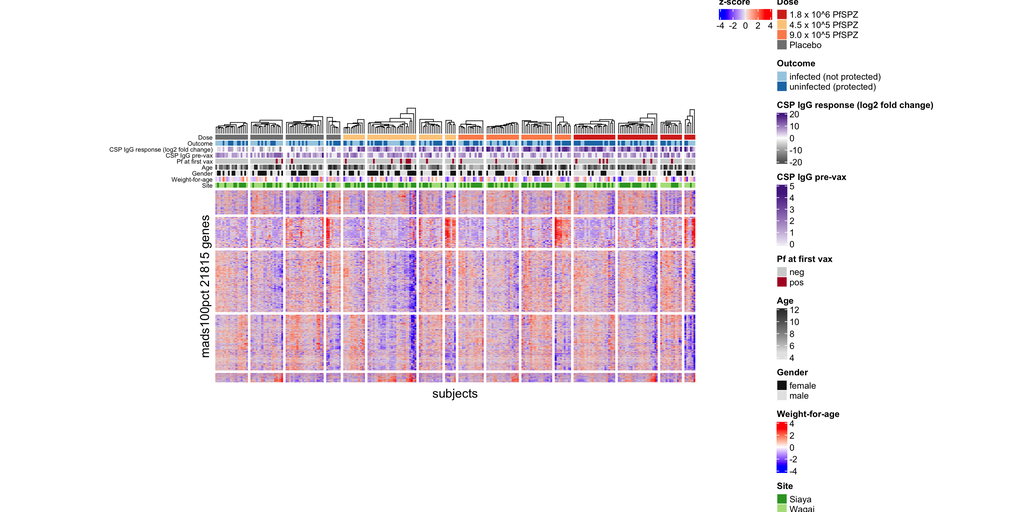

```r
hm <- draw(hm)
```

```r
c.dend <- column_dend(hm)  #Extract col dendrogram
ccl.list <- column_order(hm)  #Extract clusters (output is a list)
#lapply(ccl.list, function(x) length(x))  #check/confirm size clusters

# loop to extract samples for each cluster.
for (i in 1:length(column_order(hm))){
  if (i == 1) {
    clu <- t(t(colnames(exprs(x)[,column_order(hm)[[i]], drop = FALSE]))) #add drop = FALSE argument to prevent the matrix from becoming a vector for single column clusters
    out <- cbind(clu, paste("cluster", i, sep=""))
    colnames(out) <- c("SampleID", "Cluster")
    } else {
      clu <- t(t(colnames(exprs(x)[,column_order(hm)[[i]], drop = FALSE])))
      clu <- cbind(clu, paste("cluster", i, sep=""))
      out <- rbind(out, clu)
    }
}

## Merge with pData(x)
if(myGroup == "allGroups"){
  if(noColClust == 4){
    if(myTimepoint != "delta"){
      pData.cluster <- pData(x) %>%
        rownames_to_column(var = "SampleID") %>%
        left_join(., as_tibble(out), by = "SampleID") %>%
        column_to_rownames(var = "SampleID") %>%
        mutate(Cluster = gsub("cluster", "SC", .$Cluster)) %>%
        mutate(Cluster.pam4.cl16 = Cluster) %>%
        mutate(Cluster = gsub("5", "1", .$Cluster)) %>%
        mutate(Cluster = gsub("9", "1", .$Cluster)) %>%
        mutate(Cluster = gsub("13", "1", .$Cluster)) %>%
        mutate(Cluster = ifelse(.$Cluster != "SC1", "SC2-4", .$Cluster)) %>%
        filter(Cluster == "SC1" | Cluster == "SC2-4")
    }
  }
  }
#sanity checks
table(pData.cluster$Cluster,pData.cluster$treat)
```

```
##
##         Placebo 4.5 x 10^5 PfSPZ 9.0 x 10^5 PfSPZ 1.8 x 10^6 PfSPZ
##   SC1        18               12               14               23
##   SC2-4      47               46               44               40
```

```r
table(pData.cluster$Cluster.pam4.cl16,pData.cluster$treat)
```

```
##
##        Placebo 4.5 x 10^5 PfSPZ 9.0 x 10^5 PfSPZ 1.8 x 10^6 PfSPZ
##   SC1       18                0                0                0
##   SC10       0                0               18                0
##   SC11       0                0               17                0
##   SC12       0                0                9                0
##   SC13       0                0                0               23
##   SC14       0                0                0               22
##   SC15       0                0                0               12
##   SC16       0                0                0                6
##   SC2       18                0                0                0
##   SC3       21                0                0                0
##   SC4        8                0                0                0
##   SC5        0               12                0                0
##   SC6        0               27                0                0
##   SC7        0               13                0                0
##   SC8        0                6                0                0
##   SC9        0                0               14                0
```

```r
setdiff(colnames(x), rownames(pData.cluster))
```

```
## character(0)
```

```r
setdiff(rownames(pData.cluster), colnames(x))
```

```
## character(0)
```

## Plot stats based on clusters

```r
basefont <- "sans"
basefontsize <- 14
pvalfontsize <- 6
symnum.args <- list(cutpoints = c(0, 0.0001, 0.001, 0.01, 0.05, 1), symbols = c("****", "***", "**", "*", ""))

if(myGroup == "allGroups"){
  #OUTCOME
  foo1 <- c(1,2,3,4)
  names(foo1) <-  names(summary(pData.cluster$treat))
  for(i in names(summary(pData.cluster$treat))){
    pData.cluster.temp <- pData.cluster %>%
      filter(treat == i)
    foo1[i] <- signif(fisher.test(table("Cluster" = pData.cluster.temp$Cluster, "Outcome" = pData.cluster.temp$mal.atp.3))$p.value,2)
    foo1[i] <- ifelse(foo1[i] >= 0.05, "",
                      ifelse(foo1[i] >= 0.01 & foo1[i] < 0.05, "*",
                              ifelse(foo1[i] >= 0.001 & foo1[i] < 0.01, "**",
                                    ifelse(foo1[i] >= 0.0001 & foo1[i] < 0.001, "***", "****"))))
    }

  dat_text <- data.frame(treat = factor(levels(pData.cluster$treat),
                                        levels = levels(pData.cluster$treat)),
                         label = foo1, Cluster = levels(factor(pData.cluster.temp$Cluster)), x = 1.5, y = 25,
                         Outcome = c("not protected (infected)", "protected (uninfected)"))
  Outcome.counts <- pData.cluster %>%
    mutate(Cluster = factor(Cluster)) %>%
    mutate(Outcome = factor(mal.atp.3, levels = c(1,0), labels = c("not protected (infected)", "protected (uninfected)"))) %>%
    dplyr::filter(!(is.na(Cluster) | is.na(Outcome))) %>%
    ggplot(., aes(x=Cluster, fill = Outcome)) +
    geom_bar(position = "dodge") +
    scale_fill_manual(values = c("#A6CEE3", "#1F78B4")) +
    ylab("Outcome (count)") +
    facet_wrap(.~treat, ncol = 4) +
    theme_classic(base_family = basefont, base_size = basefontsize) +
    theme(axis.text.x=element_blank(),
          axis.ticks.x=element_blank(),
          axis.title.x=element_blank(),
          strip.background = element_rect(fill="white"),
          legend.position="none"
          ) +
      geom_text(
        data = dat_text,
        mapping = aes(x = x, y = y, label = label, size = basefontsize))

   TTE.boxplot <- pData.cluster %>%
    mutate(Outcome = factor(mal.atp.3, levels = c(1,0), labels = c("not protected (infected)", "protected (uninfected)"))) %>%
     dplyr::filter(!(is.na(tte.mal.atp.6) | is.na(Outcome))) %>%
     ggplot(., aes(Cluster, tte.mal.atp.6, fill = Outcome, color = Outcome)) +
     geom_point(position = position_jitterdodge()) +
     geom_boxplot(alpha = 0.4, color = "grey30", outlier.shape = NA) +
     stat_compare_means(aes(group = Outcome), label = "p.signif", method = "wilcox.test", label.x.npc = "center", vjust = 1, symnum.args = symnum.args) +
     scale_fill_manual(values = c("#A6CEE3", "#1F78B4")) +
     scale_color_manual(values = c("#A6CEE3", "#1F78B4")) +
     ylab("Days to first parasitemia") +
     ylim(c(0,180)) +
     facet_wrap(~treat, ncol = 4) +
     theme_classic(base_family = basefont, base_size = basefontsize) +
     theme(axis.text.x=element_blank(),
           axis.ticks.x=element_blank(),
           axis.title.x=element_blank(),
           strip.background = element_rect(fill="white"),
           legend.position="none"
           )

  #CSP Ab logFC
  CSPlogfc.boxplot <- pData.cluster %>%
    mutate(Outcome = factor(mal.atp.3, levels = c(1,0), labels = c("not protected (infected)", "protected (uninfected)"))) %>%
    dplyr::filter(!(is.na(log2FC_CSPAb) | is.na(Outcome))) %>%
    ggplot(., aes(x = Cluster, y = log2FC_CSPAb, fill = Outcome, color = Outcome)) +
    geom_point(position = position_jitterdodge()) +
    geom_boxplot(alpha = 0.4, color = "grey30", outlier.shape = NA) +
    stat_compare_means(aes(group = Outcome), label = "p.signif", method = "wilcox.test", label.x.npc = "center", vjust = 1, symnum.args = symnum.args) +
    scale_fill_manual(values = c("#A6CEE3", "#1F78B4")) +
    scale_color_manual(values = c("#A6CEE3", "#1F78B4")) +
    ylab("CSP-specific IgG (log fold change)") +
    ylim(c(-12.5,25)) +
    facet_wrap(~treat, ncol = 4) +
    theme_classic(base_family = basefont, base_size = basefontsize) +
    theme(axis.text.x=element_blank(),
          axis.ticks.x=element_blank(),
          axis.title.x=element_blank(),
          strip.text.x = element_blank(),
          strip.background = element_blank(),
          legend.position="none"
          )

  CSPbl.boxplot <- pData.cluster %>%
    mutate(Outcome = factor(mal.atp.3, levels = c(1,0), labels = c("not protected (infected)", "protected (uninfected)"))) %>%
    dplyr::filter(!(is.na(pfcsp_pre) | is.na(Outcome))) %>%
    ggplot(., aes(Cluster, log10(pfcsp_pre+1), fill = Outcome, color = Outcome)) +
    geom_point(position = position_jitterdodge()) +
    geom_boxplot(alpha = 0.4, color = "grey30", outlier.shape = NA) +
     stat_compare_means(aes(group = Outcome), label = "p.signif", method = "wilcox.test", label.x.npc = "center", vjust = 1, symnum.args = symnum.args) +
    scale_fill_manual(values = c("#A6CEE3", "#1F78B4")) +
    scale_color_manual(values = c("#A6CEE3", "#1F78B4")) +
    ylab("CSP-specific IgG at pre-vax") +
    facet_wrap(~treat, ncol = 4) +
    theme_classic(base_family = basefont, base_size = basefontsize) +
    theme(axis.text.x=element_blank(),
          axis.ticks.x=element_blank(),
          axis.title.x=element_blank(),
          strip.text.x = element_blank(),
          strip.background = element_blank(),
          legend.position="none"
          )

  foo1 <- c(1,2,3,4)
  names(foo1) <-  names(summary(pData.cluster$treat))
  pData.cluster <- pData.cluster %>%
  mutate(Cluster = factor(Cluster)) %>%
  mutate(Pf.any.vax = factor(ifelse(mal.dvax.tot == 0, 0, 1), levels = c(1,0), labels = c("pos", "neg")))
  for(i in names(summary(pData.cluster$treat))){
    pData.cluster.temp <- pData.cluster %>%
      filter(treat == i)
    foo1[i] <- signif(fisher.test(table("Cluster" = pData.cluster.temp$Cluster, "Pf during vax period" = pData.cluster.temp$Pf.any.vax))$p.value,2)
    foo1[i] <- ifelse(foo1[i] >= 0.05, "",
                      ifelse(foo1[i] >= 0.01 & foo1[i] < 0.05, "*",
                              ifelse(foo1[i] >= 0.001 & foo1[i] < 0.01, "**",
                                    ifelse(foo1[i] >= 0.0001 & foo1[i] < 0.001, "***", "****"))))
    }
dat_text <- data.frame(treat = factor(levels(pData.cluster$treat), levels = levels(pData.cluster$treat)), label = foo1, Cluster = levels(factor(pData.cluster.temp$Cluster)),
                       x = 1.5, y = 25, Pf.any.vax = c("pos", "neg"))
Pf.any.vax <- pData.cluster %>%
  dplyr::filter(!(is.na(Pf.any.vax) | is.na(Cluster))) %>%
  ggplot(., aes(x=Cluster, fill = Pf.any.vax)) +
  geom_bar(position = "dodge") +
  scale_fill_manual(values = c("#b2182b", "#D1D3D3")) +
  facet_wrap(~treat, ncol = 4) +
  ylab("Pf during vax period (counts)") +
  theme_classic(base_family = basefont, base_size = basefontsize) +
  theme(axis.text.x=element_blank(),
        axis.ticks.x=element_blank(),
        axis.title.x=element_blank(),
        strip.text.x = element_blank(),
        strip.background = element_blank(),
        legend.position="none"
        ) +
  geom_text(
    data = dat_text,
    mapping = aes(x = x, y = y, label = label, size = basefontsize))
```

```r
  mal.dvax.tot.boxplot <- pData.cluster %>%
    mutate(Outcome = factor(mal.atp.3, levels = c(1,0), labels = c("not protected (infected)", "protected (uninfected)"))) %>%
    dplyr::filter(!(is.na(mal.dvax.tot) | is.na(Outcome))) %>%
    ggplot(., aes(Cluster, mal.dvax.tot, fill = Outcome, color = Outcome)) +
    geom_point(position = position_jitterdodge()) +
    geom_boxplot(alpha = 0.4, color = "grey30", outlier.shape = NA) +
     stat_compare_means(aes(group = Outcome), label = "p.signif", method = "wilcox.test", label.x.npc = "center", vjust = 1, symnum.args = symnum.args) +
    scale_fill_manual(values = c("#A6CEE3", "#1F78B4")) +
    scale_color_manual(values = c("#A6CEE3", "#1F78B4")) +
    ylab("# Pf episodes during vax") +
    ylim(c(0,6.5)) +
    facet_wrap(~treat, ncol = 4) +
    theme_classic(base_family = basefont, base_size = basefontsize) +
    theme(axis.text.x=element_blank(),
          axis.ticks.x=element_blank(),
          axis.title.x=element_blank(),
          strip.text.x = element_blank(),
          strip.background = element_blank(),
          legend.position="none"
          )

    foo1 <- c(1,2,3,4)
    names(foo1) <-  names(summary(pData.cluster$treat))
    pData.cluster <- pData.cluster %>%
      mutate(Cluster = factor(Cluster)) %>%
      mutate(Pf = factor(mal.vax.1, levels = c(1,0), labels = c("pos", "neg")))
    for(i in names(summary(pData.cluster$treat))){
      pData.cluster.temp <- pData.cluster %>%
        filter(treat == i)
      foo1[i] <- signif(fisher.test(table("Cluster" = pData.cluster.temp$Cluster, "Pf at Vax1" = pData.cluster.temp$Pf))$p.value,2)
      foo1[i] <- ifelse(foo1[i] >= 0.05, "",
                      ifelse(foo1[i] >= 0.01 & foo1[i] < 0.05, "*",
                              ifelse(foo1[i] >= 0.001 & foo1[i] < 0.01, "**",
                                    ifelse(foo1[i] >= 0.0001 & foo1[i] < 0.001, "***", "****"))))
      }
    dat_text <- data.frame(treat = factor(levels(pData.cluster$treat), levels = levels(pData.cluster$treat)), label = foo1, Cluster = levels(factor(pData.cluster.temp$Cluster)),
                           x = 1.5, y = 45,
                           Pf = c("pos","neg"))
  Pf.counts <-  pData.cluster %>%
    dplyr::filter(!(is.na(Cluster) | is.na(Pf))) %>%
    ggplot(., aes(x=Cluster, fill = Pf)) +
    geom_bar(position = "dodge") +
    scale_fill_manual(values = c("#b2182b", "#D1D3D3")) +
    ylab("Pf at first vax (counts)") +
    facet_wrap(~treat, ncol = 4) +
    theme_classic(base_family = basefont, base_size = basefontsize) +
  theme(axis.ticks.x=element_blank(),
        axis.title.x=element_blank(),
        strip.text.x = element_blank(),
        strip.background = element_blank(),
        legend.position="none"
        ) +
  geom_text(data = dat_text,mapping = aes(x = x, y = y, label = label, size = basefontsize))


    foo1 <- c(1,2,3,4)
    names(foo1) <-  names(summary(pData.cluster$treat))
    pData.cluster <- pData.cluster %>%
    mutate(Site = factor(site))
    for(i in names(summary(pData.cluster$treat))){
      pData.cluster.temp <- pData.cluster %>%
        filter(treat == i)
      foo1[i] <- signif(fisher.test(table("Cluster" = pData.cluster.temp$Cluster, "Site" = pData.cluster.temp$Site))$p.value,2)
      foo1[i] <- ifelse(foo1[i] >= 0.05, "",
                      ifelse(foo1[i] >= 0.01 & foo1[i] < 0.05, "*",
                              ifelse(foo1[i] >= 0.001 & foo1[i] < 0.01, "**",
                                    ifelse(foo1[i] >= 0.0001 & foo1[i] < 0.001, "***", "****"))))
      }
    dat_text <- data.frame(treat = factor(levels(pData.cluster$treat), levels = levels(pData.cluster$treat)), label = foo1, Cluster = levels(factor(pData.cluster.temp$Cluster)),
                           x = 1.5, y = 25,
                           Site = c("Siaya","Wagai"))

  Site.counts <- pData.cluster %>%
    dplyr::filter(!(is.na(Cluster) | is.na(Site))) %>%
    ggplot(., aes(x= Cluster, fill = Site)) +
    geom_bar(position = "dodge") +
    scale_fill_manual(values = c("#33A02C","#B2DF8A")) +
    ylab("Site (counts)") +
    facet_wrap(~treat, ncol = 4) +
    theme_classic(base_family = basefont, base_size = basefontsize) +
  theme(axis.ticks.x=element_blank(),
        axis.title.x=element_blank(),
        strip.text.x = element_blank(),
        strip.background = element_blank(),
        legend.position="none"
        ) +
  geom_text(data = dat_text,mapping = aes(x = x, y = y, label = label, size = basefontsize))


  Age.boxplot <- pData.cluster %>%
    mutate(Outcome = factor(mal.atp.3, levels = c(1,0), labels = c("not protected (infected)", "protected (uninfected)"))) %>%
    dplyr::filter(!(is.na(Outcome) | is.na(age.vax1))) %>%
    ggplot(., aes(Cluster, age.vax1, fill = Outcome, color = Outcome)) +
    geom_point(position = position_jitterdodge()) +
    geom_boxplot(alpha = 0.4, color = "grey30", outlier.shape = NA) +
     stat_compare_means(aes(group = Outcome), label = "p.signif", method = "wilcox.test", label.x.npc = "center", vjust = 1, symnum.args = symnum.args) +
    scale_fill_manual(values = c("#A6CEE3", "#1F78B4")) +
    scale_color_manual(values = c("#A6CEE3", "#1F78B4")) +
    ylab("Age at first vax (months)") +
    facet_wrap(~treat, ncol = 4) +
    theme_classic(base_family = basefont, base_size = basefontsize) +
    theme(axis.text.x=element_blank(),
          axis.ticks.x=element_blank(),
          axis.title.x=element_blank(),
          strip.text.x = element_blank(),
          strip.background = element_blank(),
          legend.position="none"
          )

    foo1 <- c(1,2,3,4)
    names(foo1) <-  names(summary(pData.cluster$treat))
    pData.cluster <- pData.cluster %>%
      mutate(Gender = factor(SEX))
    for(i in names(summary(pData.cluster$treat))){
      pData.cluster.temp <- pData.cluster %>%
        filter(treat == i)
      foo1[i] <- signif(fisher.test(table("Cluster" = pData.cluster.temp$Cluster, "Gender" = pData.cluster.temp$Gender))$p.value,2)
      foo1[i] <- ifelse(foo1[i] >= 0.05, "",
                      ifelse(foo1[i] >= 0.01 & foo1[i] < 0.05, "*",
                              ifelse(foo1[i] >= 0.001 & foo1[i] < 0.01, "**",
                                    ifelse(foo1[i] >= 0.0001 & foo1[i] < 0.001, "***", "****"))))
      }
    dat_text <- data.frame(treat = factor(levels(pData.cluster$treat), levels = levels(pData.cluster$treat)), label = foo1, Cluster = levels(factor(pData.cluster.temp$Cluster)),
                           x = 1.5, y = 27.5,
                           Gender = c("F","M"))
```

```r
  Gender.counts <- pData.cluster %>%
    dplyr::filter(!(is.na(Cluster) | is.na(Gender))) %>%
    ggplot(., aes(x=Cluster, fill = Gender)) +
    geom_bar(position = "dodge") +
    scale_fill_manual(values = c("#191919", "#E5E5E5")) +
    ylab("Gender (counts)") +
    facet_wrap(~treat, ncol = 4) +
    theme_classic(base_family = basefont, base_size = basefontsize) +
  theme(axis.ticks.x = element_blank(),
        axis.text.x = element_blank(),
        axis.title.x = element_blank(),
        strip.text.x = element_blank(),
        strip.background = element_blank(),
        legend.position="none"
        ) +
  geom_text(data = dat_text,mapping = aes(x = x, y = y, label = label, size = basefontsize))


  DaysPreVax.boxplot <- pData.cluster %>%
    mutate(Outcome = factor(mal.atp.3, levels = c(1,0), labels = c("not protected (infected)", "protected (uninfected)"))) %>%
    dplyr::filter(!(is.na(Cluster) | is.na(DaysPriorVax1))) %>%
    ggplot(., aes(Cluster, DaysPriorVax1, fill = Outcome, color = Outcome)) +
    geom_point(position = position_jitterdodge()) +
    geom_boxplot(alpha = 0.4, color = "grey30", outlier.shape = NA) +
     stat_compare_means(aes(group = Outcome), label = "p.signif", method = "wilcox.test", label.x.npc = "center", vjust = 1, symnum.args = symnum.args) +
    scale_fill_manual(values = c("#A6CEE3", "#1F78B4")) +
    scale_color_manual(values = c("#A6CEE3", "#1F78B4")) +
    ylab("Days before first dose") +
    facet_wrap(~treat, ncol = 4) +
    theme_classic(base_family = basefont, base_size = basefontsize) +
    theme(axis.text.x=element_blank(),
          axis.ticks.x=element_blank(),
          axis.title.x=element_blank(),
          strip.text.x = element_blank(),
          strip.background = element_blank(),
          legend.position="none"
          )

  Weight4Age <- pData.cluster %>%
    mutate(Outcome = factor(mal.atp.3, levels = c(1,0), labels = c("not protected (infected)", "protected (uninfected)"))) %>%
    dplyr::filter(!(is.na(Outcome) | is.na(zwei))) %>%
    ggplot(., aes(Cluster, zwei, fill = Outcome, color = Outcome)) +
    geom_point(position = position_jitterdodge()) +
    geom_boxplot(alpha = 0.4, color = "grey30", outlier.shape = NA) +
     stat_compare_means(aes(group = Outcome), label = "p.signif", method = "wilcox.test", label.x.npc = "center", vjust = 1, symnum.args = symnum.args) +
    scale_fill_manual(values = c("#A6CEE3", "#1F78B4")) +
    scale_color_manual(values = c("#A6CEE3", "#1F78B4")) +
    ylab("weight-for-age z-score") +
    facet_wrap(~treat, ncol = 4) +
    theme_classic(base_family = basefont, base_size = basefontsize) +
    theme(axis.text.x=element_blank(),
          axis.ticks.x=element_blank(),
          axis.title.x=element_blank(),
          strip.text.x = element_blank(),
          strip.background = element_blank(),
          legend.position="none"
    )
  }
```

## Print column annotation bar and box plots (Figure S2 in pre-print)

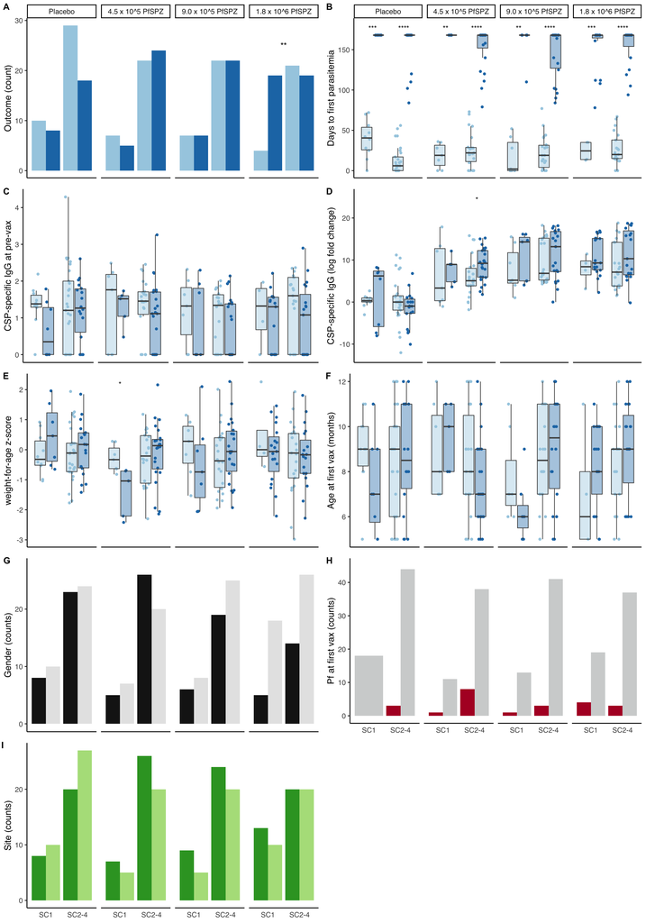

```r
print(ggarrange(
  Outcome.counts,
  TTE.boxplot,
  CSPbl.boxplot,
  CSPlogfc.boxplot,
  Weight4Age,
  Age.boxplot,
  Gender.counts,
  Pf.counts,
  Site.counts,
  labels = "AUTO",
  ncol = 2,
  nrow = 5)
  )
```

```r
cairo_pdf(filename = paste0(figdir, "Fig S2 Revision.pdf"), height = 8, width = 8)
print(ggarrange(
  Outcome.counts,
  TTE.boxplot,
  CSPbl.boxplot,
  CSPlogfc.boxplot,
  Weight4Age,
  Age.boxplot,
  Gender.counts,
  Pf.counts,
  Site.counts,
  labels = "AUTO",
  ncol = 2,
  nrow = 5)
  )
dev.off()
```

## Extract clustering information for rows (genes)

Note: may have to run this chunk directly in console if you get an error:

Error: The width or height of the raster image is zero, maybe you forget to turn off the previous graphic device or it was corrupted. Run `dev.off()` to close it.

see https://github.com/jokergoo/ComplexHeatmap/issues/136

```r
r.dend <- row_dend(hm)  #Extract col dendrogram
rcl.list <- row_order(hm)  #Extract clusters (output is a list)
#lapply(rcl.list, function(x) length(x))  #check/confirm size clusters

# loop to extract samples for each cluster.

for (i in 1:length(row_order(hm))){
  if (i == 1) {
    clu <- t(t(rownames(exprs(x)[row_order(hm)[[i]],])))
    out <- cbind(clu, paste("cluster", i, sep=""))
    colnames(out) <- c("GeneID", "Cluster")
    } else {
      clu <- t(t(rownames(exprs(x)[row_order(hm)[[i]],])))
      clu <- cbind(clu, paste("cluster", i, sep=""))
      out <- rbind(out, clu)
    }
  }
```

## Merge with fData(x)

```r
#for baseline, we use the logcpm expression for all infants but limited to genes in GC2 and rank by expression
if(myGroup == "allGroups"){
  if(myTimepoint == 0){
    if(noRowClust == 5){
      fData.cluster <- fData(unscaled_logCPM) %>%
        dplyr::rename(GeneID = EnsemblID) %>%
        left_join(., as_tibble(out), by = "GeneID") %>%
        column_to_rownames(var = "GeneID") %>%
        mutate(Cluster = gsub("cluster", "GC", .$Cluster))
      }
    setdiff(rownames(unscaled_logCPM), rownames(fData.cluster))
    setdiff(rownames(fData.cluster), rownames(unscaled_logCPM))
    #make long version for plotting
    c12.long <- fData.cluster %>%
      dplyr::select(GeneSymbol, Cluster) %>%
      rownames_to_column(var = "EnsemblID") %>%
      left_join(., exprs(unscaled_logCPM) %>%
                  as.data.frame() %>%
                  rownames_to_column(var = "EnsemblID"),
                by = "EnsemblID") %>%
      pivot_longer(cols = 4:ncol(.), names_to = "SAMPLEID", values_to = "logCPM") %>%
      dplyr::rename(GeneCluster = "Cluster") %>%
      right_join(., pData.cluster %>%
                   dplyr::select(SAMPLEID, treat, Cluster, Cluster.pam4.cl16) %>%
                   mutate(SampleCluster = ifelse(Cluster.pam4.cl16 %in% c("SC1", "SC5", "SC9", "SC13"), "SC1",
                                                 ifelse(Cluster.pam4.cl16 %in% c("SC2", "SC6", "SC10", "SC14"), "SC2",
                                                        ifelse(Cluster.pam4.cl16 %in% c("SC3", "SC7", "SC11", "SC15"), "SC3", "SC4")))),
                 by = "SAMPLEID")
    #Calculate average of means and average of variances of genes in each cluster
    c12.long %>%
      dplyr::group_by(GeneSymbol, EnsemblID, GeneCluster) %>%
      summarise(mean = mean(logCPM), median = median(logCPM)) %>%
      ungroup() %>%
      group_by(GeneCluster) %>%
      summarise(n_of_genes = n(), mean_of_means = mean(mean, na.rm = TRUE), median_of_medians = median(median, na.rm = TRUE))
    #Calculate median expression as a ranking metric in sample CL1 and gene CL2
    c12.long.summarized <- fData.cluster %>%
      dplyr::filter(Cluster == "GC2") %>% #filter on gene cluster 2, which is the lowest expressing cluster at baseline
      dplyr::select(GeneSymbol, Cluster) %>%
      rownames_to_column(var = "EnsemblID") %>%
      left_join(., exprs(unscaled_logCPM) %>%
                  as.data.frame() %>%
                  rownames_to_column(var = "EnsemblID"),
                by = "EnsemblID") %>%
      filter(EnsemblID != "ENSG00000249428") %>% #remove duplicate CFAP99 transcript ENSG00000249428 that is no longer in database
      pivot_longer(cols = 4:ncol(.), names_to = "SAMPLEID", values_to = "logCPM") %>%
      dplyr::rename(GeneCluster = "Cluster") %>%
      right_join(., pData.cluster %>%
                   dplyr::select(SAMPLEID, treat, Cluster) %>%
                   dplyr::rename(SampleCluster = "Cluster"),
                 by = "SAMPLEID")
    #Genes within GC2 ranked by a metric
    cl12.summarized <- c12.long.summarized %>%
      group_by(GeneSymbol, EnsemblID) %>%
      summarise(n_of_samples = n(), mean_logCPM = mean(logCPM), median_logCPM = median(logCPM), variance_logCPM = var(logCPM)) %>%
      mutate(newRankMetric = mean_logCPM) %>%
      arrange(desc(newRankMetric)) %>%
      ungroup()
    cl12.summarized <- cl12.summarized %>%
      dplyr::select(GeneSymbol, newRankMetric) %>%
      arrange(desc(newRankMetric))
    cl12.ranklist <- data.frame(GeneSymbol = cl12.summarized$GeneSymbol, newRankMetric = cl12.summarized$newRankMetric) %>%
      arrange(desc(newRankMetric))
  }
}
```

## Plot logcpm of genes in each cluster by SampleCluster

```r
my_comparisons <- list( c("SC1", "SC2"), c("SC1", "SC3"), c("SC1", "SC4") )
myErrorPlot <- c12.long %>%
  ggerrorplot(., x = "SampleCluster", y = "logCPM", color = "SampleCluster", fill = "SampleCluster",
                      desc_stat = "mean_sd", palette = "npg", add.params = list(color = "darkgray"),
              size = 0.5) +
  stat_compare_means(comparisons = my_comparisons, # Add pairwise comparisons p-value
                     method = "t.test",
                     symnum.args = list(cutpoints = c(0, 0.0001/3, 0.001/3, 0.01/3, 0.05/3, 1),
                                        symbols = c("****", "***", "**", "*", "ns")),
                     vjust = 0.5) +
  grids(linetype = "dotted", axis = "y", size = 1, color = "grey60") +
  theme(strip.background = element_blank(),
        axis.text.x = element_text(angle = 90, vjust = 0.5, hjust=1)) +
  facet_wrap(~GeneCluster, ncol = 1, nrow = 5, strip.position = "left")

myErrorPlot_GC2_only <- c12.long %>%
  filter(GeneCluster == "GC2") %>%
  ggerrorplot(., x = "SampleCluster", y = "logCPM", color = "SampleCluster", fill = "SampleCluster",
                      desc_stat = "mean_sd", palette = "npg", add.params = list(color = "darkgray"),
              size = 0.5) +
  stat_compare_means(comparisons = my_comparisons, # Add pairwise comparisons p-value
                     method = "t.test",
                     symnum.args = list(cutpoints = c(0, 0.0001/3, 0.001/3, 0.01/3, 0.05/3, 1),
                                        symbols = c("****", "***", "**", "*", "ns")),
                     vjust = 1) +
  grids(linetype = "dotted", axis = "y", size = 1, color = "grey60") +
  theme(strip.background = element_blank(),
        axis.text.x = element_text(angle = 90, vjust = 0.5, hjust=1))
```

## Print error plot of Gene Expression (Figure 1D)

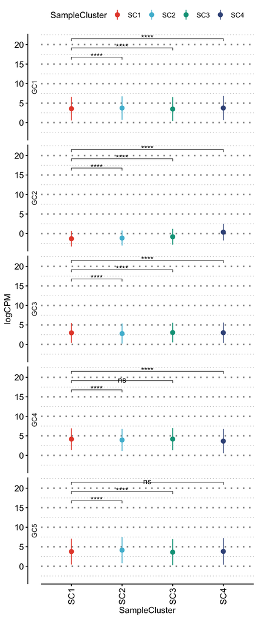

```r
print(myErrorPlot)
```

## Apply GSEA to Genes within Cluster ranked by AveCPM

Ranking is by mean logCPM for each gene in GC2 for ALL samples at baseline (n=244). Uses NamedGeneRankList2GseaTable helper function: https://github.com/TranLab/ModuleLists/blob/main/NamedGeneRankList2GseaTable.R

```r
set.seed(23)
#https://stephenturner.github.io/deseq-to-fgsea/
#https://www.biostars.org/p/429563/
#https://www.biostars.org/p/465848/

if(myTimepoint == 0){
ranks <- deframe(cl12.ranklist)
}
if(myTimepoint == 0){
devtools::source_url("https://github.com/TranLab/ModuleLists/blob/main/NamedGeneRankList2GseaTable.R?raw=TRUE")
GSEA_baseline_bound_df <- NamedGeneRankList2GseaTable(rankedgenes = ranks, geneset = "bloodmodules", output_directory = tempdir(), filename_prefix = paste0("PfSPZ_GSEA_", myTimepoint,
"_GeneCluster2_minSize20"), scoreType = "pos", minSize = 20, fixed_seed = TRUE)
}
```

```
## [1] "Running fgsea for MonacoModules signatures"
## [1] "Running fgsea for highBTMs signatures"
## [1] "Running fgsea for lowBTMs signatures"
## [1] "Running fgsea for BloodGen3Module signatures"
```

## Make GSEA plot for figure

Take results from fgseaMultiLevel analysis, cleans up names, and filters based on FDR.

```r
myGSEAClusterPlotDat <- readxl::read_excel(paste0(tempdir(),
                                                  "PfSPZ_GSEA_", myTimepoint,"_GeneCluster2_minSize20",
                                                  " GSEA results bloodmodules.xlsx")) %>%
  filter(padj < 0.05) %>%
  mutate(neglogpadj = -log10(padj)) %>%
  mutate(pathway = gsub("VS", "v", pathway)) %>%
  mutate(pathway = gsub("Vd", "Vδ", pathway)) %>%
  mutate(pathway = gsub("gd", "γδ", pathway)) %>%
  mutate(pathway = sub(".*?\\_", "", pathway)) %>%
  mutate(pathway = fct_reorder(pathway, NES, .desc = TRUE)) %>%
  dplyr::filter(!grepl("NEURON", pathway)) %>%
  mutate(pathway = fct_reorder(pathway, neglogpadj)) %>%
  mutate(TextLabelColor = ifelse(module_type == "lowBTMs", scales::muted("red"),
                                 ifelse(module_type == "highBTMs", scales::muted("blue"),
                                        ifelse(module_type == "MonacoModules", "black","gray")))) %>%
  arrange(desc(neglogpadj))
myGSEAClusterPlot <- myGSEAClusterPlotDat %>%
  ggplot(., aes(x = NES, y = pathway, fill = neglogpadj)) +
  geom_bar(stat = 'identity') +
  viridis::scale_fill_viridis(option= "A", begin = 0.25, end = 0.75, alpha = 0.8, direction = -1, name = "neglogpadj") +
  theme_classic(base_family = "sans", base_size = 12) +
  theme(legend.position = "bottom", axis.text.y = element_text(colour = rev(myGSEAClusterPlotDat$TextLabelColor)))

#Helper function courtesy of: https://stackoverflow.com/questions/52297978/decrease-overal-legend-size-elements-and-text
addSmallLegend <- function(myPlot, pointSize = 4, textSize = 6, spaceLegend = 1) {
    myPlot +
        guides(shape = guide_legend(override.aes = list(size = pointSize)),
               color = guide_legend(override.aes = list(size = pointSize))) +
        theme(legend.title = element_text(size = textSize),
              legend.text  = element_text(size = textSize),
              legend.key.size = unit(spaceLegend, "lines"))
}
```

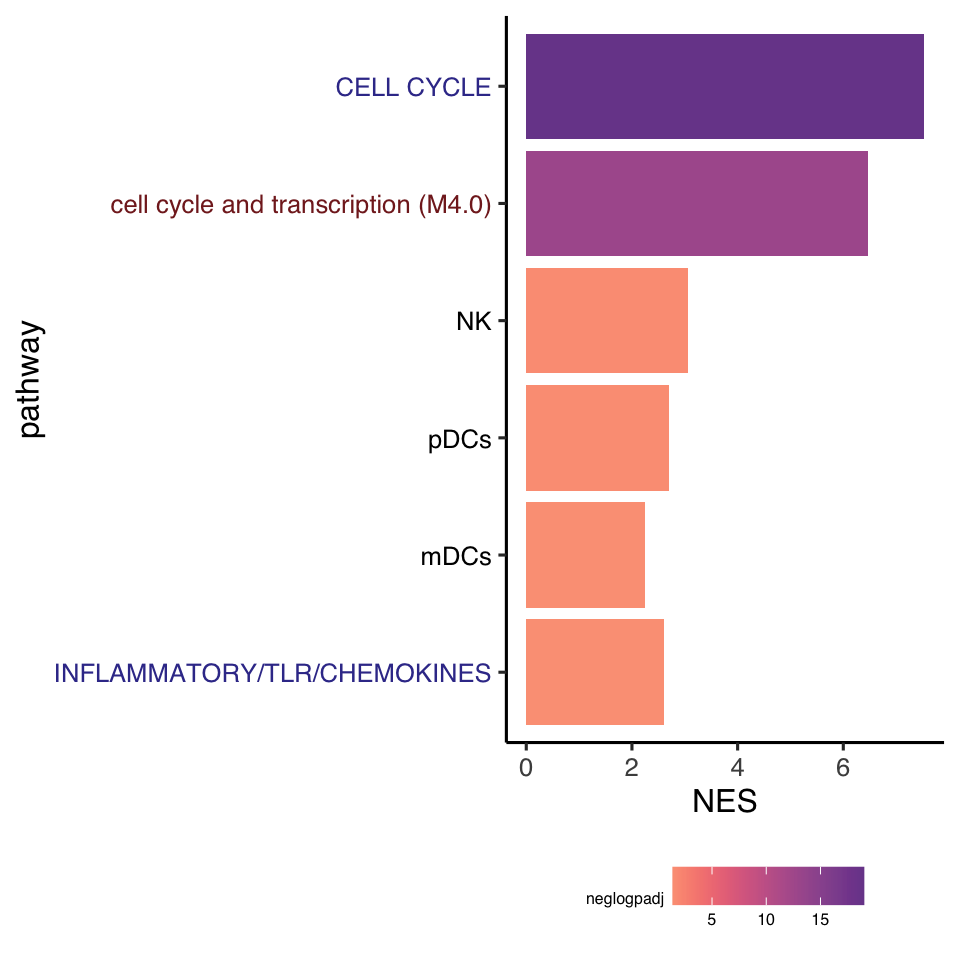

```r
addSmallLegend(myGSEAClusterPlot)
```